# Lab 06 Activity Key

Author

Published

### Activity Objectives:

- Calculate Cohen’s $d$
- Perform a power analysis

### Instructions:

- Fill in the code chunks
- Render the Quarto document and submit both the `.qmd` and `.html` file on Canvas

## Activity

### 1) If you’d like to load packages with `library()`, please do so in this block.

```r
library(tidyverse)
library(palmerpenguins)
```

## Effect Size

NOTE: this dataset does contain some missing values! The `effectsize` package functions will handle those by dropping rows with missing values, but they may throw a warning.

```r
glimpse(penguins)
```

```
Rows: 344
Columns: 8
$ species           <fct> Adelie, Adelie, Adelie, Adelie, Adelie, Adelie, Adel…
$ island            <fct> Torgersen, Torgersen, Torgersen, Torgersen, Torgerse…
$ bill_length_mm    <dbl> 39.1, 39.5, 40.3, NA, 36.7, 39.3, 38.9, 39.2, 34.1, …
$ bill_depth_mm     <dbl> 18.7, 17.4, 18.0, NA, 19.3, 20.6, 17.8, 19.6, 18.1, …
$ flipper_length_mm <int> 181, 186, 195, NA, 193, 190, 181, 195, 193, 190, 186…
$ body_mass_g       <int> 3750, 3800, 3250, NA, 3450, 3650, 3625, 4675, 3475, …
$ sex               <fct> male, female, female, NA, female, male, female, male…
$ year              <int> 2007, 2007, 2007, 2007, 2007, 2007, 2007, 2007, 2007…
```

### 3) Your colleague is a penguin researcher, and they suspect that there is a difference in flipper length between male and female penguins, but they aren’t sure how much. Calculate the Cohen’s $d$ value of the difference between flipper lengths (`flipper_length_mm`) by penguin sex (`sex`).

```r
effectsize::cohens_d(penguins$flipper_length_mm,
                     penguins$sex)
```

```
Cohen's d |         95% CI
--------------------------
-0.53     | [-0.74, -0.31]

- Estimated using pooled SD.
```

### 4) Briefly interpret this effect size.

### 5) Next, your colleague wants to better understand the difference in size between penguins’ bill length `bill_length_mm` and bill depth `bill_depth_mm`. Calculate the appropriate Cohen’s $d$ value.

```r
effectsize::cohens_d(penguins$bill_length_mm,
                     penguins$bill_depth_mm,
                     paired = T)
```

```
For paired samples, 'repeated_measures_d()' provides more options.
```

```
Cohen's d |       95% CI
------------------------
4.30      | [3.96, 4.64]
```

### 6) Briefly interpret this effect size.

## Power Analysis

### 7) Calculate the power for a two-sample *t*-test with a true effect size of $\delta = 0.4$, sample size of 100 participants across groups, and significance level of $\alpha = .05$.

```r
pwr::pwr.t.test(
  n = 50,,
  d = 0.4,
  sig.level = .05
)
```

```
     Two-sample t test power calculation

              n = 50
              d = 0.4
      sig.level = 0.05
          power = 0.5081857
    alternative = two.sided

NOTE: n is number in *each* group
```

- Calculate power for varying levels of $N$
- Create a power curve with sample size on the x-axis and power on the y-axis
- What sample size do you recommend?

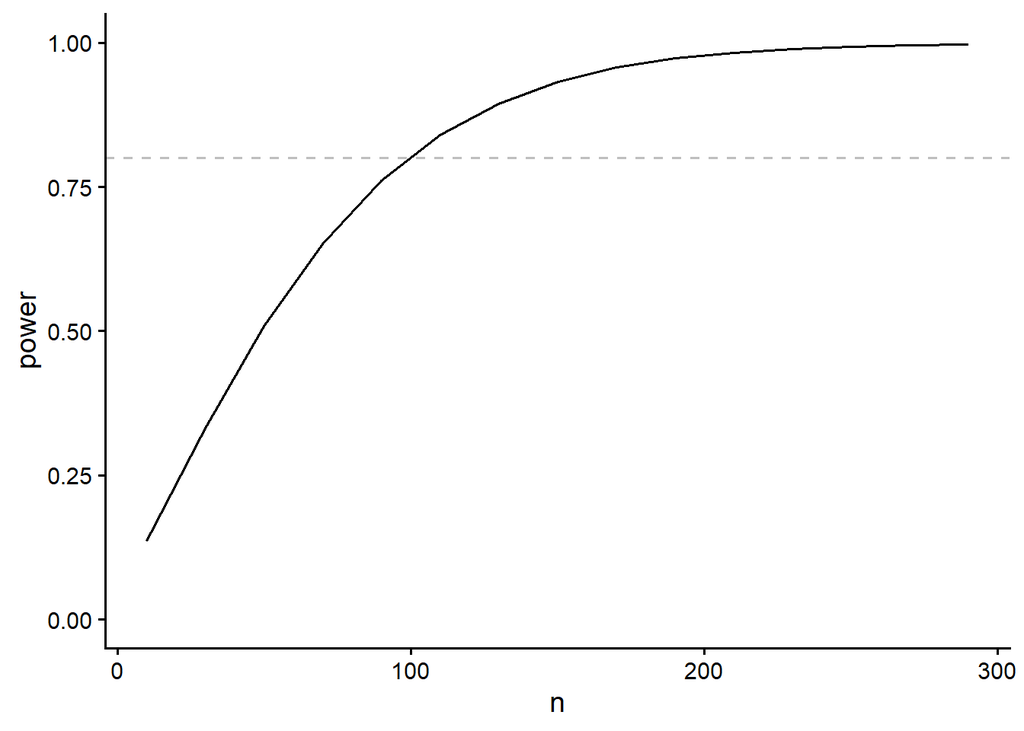

```r
sample_sizes <- seq(10, 300, by = 20)
power_values <- map_dbl(
  sample_sizes,
  function(sample_size)
    pwr::pwr.t.test(
      n = sample_size,
      d = 0.4,
      sig.level = 0.05)$power
)

tibble(n = sample_sizes,
       power = power_values) |>
  ggplot(aes(x = n, y = power)) +
  geom_hline(aes(yintercept = 0.8), linetype = "dashed", color = "gray75") +
  geom_line() +
  coord_cartesian(ylim = c(0, 1)) +
  theme_classic(base_size = 14)
```